# ImmunoMarkers

```python
%matplotlib inline
import numpy as np
import matplotlib.pyplot as plt
import pandas as pd
import seaborn as sns
import statsmodels.formula.api as smf
import statsmodels.api as sm
from statsmodels.formula.api import logit
from scipy import stats
import pymc3 as pm
import warnings
warnings.filterwarnings('ignore')
pd.options.display.max_rows = 400
pd.options.display.max_columns = 400
```

## Load Parasitology Data

```python
#Import parasitology results from 2014-2015.
para_results = pd.read_excel("Results_Updated_2014_2015.xlsx")
```

```python
#Summary of parasitology data.
para_results.describe()
```

|  | Order | Date | Ward Name | RNONE | RNONE_Results | RBHOM | RBHOM_Results | RDFRG | RDFRG_Results | RNANA | RNANA_Results | RCOLI | RCOLI_Results | RHART | RHART_Results | RCHIL | RCHIL_Results | RGIAR | RGIAR_Results | RHIS2 | RHIS2_Results | RIODA | RIODA_Results | RTRIC | RTRIC_Results | EIAH | EIAH_Results | EIAG | EIAG_Results | … |
| --- | --- | --- | --- | --- | --- | --- | --- | --- | --- | --- | --- | --- | --- | --- | --- | --- | --- | --- | --- | --- | --- | --- | --- | --- | --- | --- | --- | --- | --- | --- |
| count | 129172 | 129172 | 129172 | 115093 | 115093 | 10179 | 10179 | 2967 | 2967 | 1563 | 1563 | 970 | 970 | 382 | 382 | 319 | 319 | 223 | 223 | 197 | 197 | 122 | 122 | 64 | 64 | 311 | 311 | 277 | 277 | … |
| unique | 129172 | 617 | 6540 | 1 | 1 | 1 | 4 | 1 | 4 | 1 | 15 | 1 | 12 | 1 | 11 | 1 | 12 | 1 | 12 | 1 | 14 | 1 | 13 | 1 | 4 | 3 | 1 | 3 | 1 | … |
| top | H5300868 | 2014-02-05 00:00:00 | Referring Atlanta | RNONE | NONE | RBHOM | MOD | RDFRG | FEW TROPH(S) | RNANA | FEW T/C | RCOLI | FEW T/C | RHART | FEW T/C | RCHIL | MOD T/C | RGIAR | RARE CYST(S) | RHIS2 | FEW T/C W/O RBC | RIODA | MOD T/C | RTRIC | MANY TROPH(S) | 2EIAH | Positive | C2EIG | Positive | … |
| freq | 1 | 519 | 24788 | 115093 | 115093 | 10179 | 3252 | 2967 | 1023 | 1563 | 312 | 970 | 231 | 382 | 91 | 319 | 63 | 223 | 56 | 197 | 57 | 122 | 30 | 64 | 21 | 162 | 311 | 158 | 277 | … |
| first | NaN | 2014-01-02 00:00:00 | NaN | NaN | NaN | NaN | NaN | NaN | NaN | NaN | NaN | NaN | NaN | NaN | NaN | NaN | NaN | NaN | NaN | NaN | NaN | NaN | NaN | NaN | NaN | NaN | NaN | NaN | NaN | … |
| last | NaN | 2015-12-31 00:00:00 | NaN | NaN | NaN | NaN | NaN | NaN | NaN | NaN | NaN | NaN | NaN | NaN | NaN | NaN | NaN | NaN | NaN | NaN | NaN | NaN | NaN | NaN | NaN | NaN | NaN | NaN | NaN | … |

## Load and Clean Immunology Data

```python
#Import immunology markers from 2014-2015.
immuno_results = pd.read_excel("immuno_results_2014_2015.xlsx")
```

```python
#Number of tests by test code.
immuno_results.atestid.value_counts()
```

```
CCAL     64831
CSIGA    64822
CAL1     56598
FLF01    15382
FLF03    14464
Name: atestid, dtype: int64
```

```python
#Split results and demographics.
demographics = immuno_results[["asord", "sex", "dob", "state"]]
immuno_results = immuno_results.drop(["sex", "dob", "state"], axis=1)

#Split results apart based on immunology test.
calpro = immuno_results[(immuno_results.atestid == "CCAL") | (immuno_results.atestid == "CAL1")]
lactoferrin = immuno_results[(immuno_results.atestid == "FLF01") | (immuno_results.atestid == "FLF03")]
siga = immuno_results[(immuno_results.atestid == "CSIGA")]

#Rename results columns.
calpro = calpro.rename(columns={'atestid': 'calpro', 'aresult': 'calpro_results'})
lactoferrin = lactoferrin.rename(columns={'atestid': 'lactoferrin', 'aresult': 'lactoferrin_results'})
siga = siga.rename(columns={'atestid': 'siga', 'aresult': 'siga_results'})
```

```python
#Merge immunology markers together based on order ID.
imm = calpro.merge(lactoferrin, how='outer', on=["asord", "aodate"]).merge(siga, how='outer', on=["asord", "aodate"])
#Set date columns to datetime object.
imm.aodate = pd.to_datetime(imm.aodate)
#Sort by date.
imm = imm.sort_values(by='aodate').reset_index(drop=True)
#Drop duplicates.
imm = imm.drop_duplicates('asord')
#Rearrange columns.
imm = imm[["asord", "aodate", "calpro", "calpro_results", "lactoferrin", "lactoferrin_results", "siga", "siga_results"]]
```

## Immunology Data Overview

```python
#First five rows of resulting table.
#Each row is unique sample with associated immunology results reported for that sample.
#NaN means that a particular test wasn't ordered for that sample.
imm.head()
```

|  | asord | aodate | calpro | calpro_results | lactoferrin | lactoferrin_results | siga | siga_results |
| --- | --- | --- | --- | --- | --- | --- | --- | --- |
| 0 | G9020153 | 2014-01-02 | CAL1 | <16 | NaN | NaN | NaN | NaN |
| 1 | G9020192 | 2014-01-02 | CAL1 | 20 | NaN | NaN | NaN | NaN |
| 2 | G9020169 | 2014-01-02 | NaN | NaN | FLF01 | Negative | NaN | NaN |
| 3 | G9020125 | 2014-01-02 | CAL1 | 735 | NaN | NaN | NaN | NaN |
| 4 | G9020158 | 2014-01-02 | CAL1 | 641 | NaN | NaN | NaN | NaN |

```python
#Summary of immunology data.
imm.describe()
```

|  | asord | aodate | calpro | calpro_results | lactoferrin | lactoferrin_results | siga | siga_results |
| --- | --- | --- | --- | --- | --- | --- | --- | --- |
| count | 137128 | 137128 | 121428 | 121410 | 29846 | 29846 | 64821 | 64815 |
| unique | 137128 | 617 | 2 | 2027 | 2 | 4 | 1 | 2761 |
| top | I9300268 | 2015-05-28 00:00:00 | CCAL | <16 | FLF01 | Negative | CSIGA | <dl |
| freq | 1 | 543 | 64830 | 39310 | 15382 | 27507 | 64821 | 6493 |
| first | NaN | 2014-01-02 00:00:00 | NaN | NaN | NaN | NaN | NaN | NaN |
| last | NaN | 2015-12-30 00:00:00 | NaN | NaN | NaN | NaN | NaN | NaN |

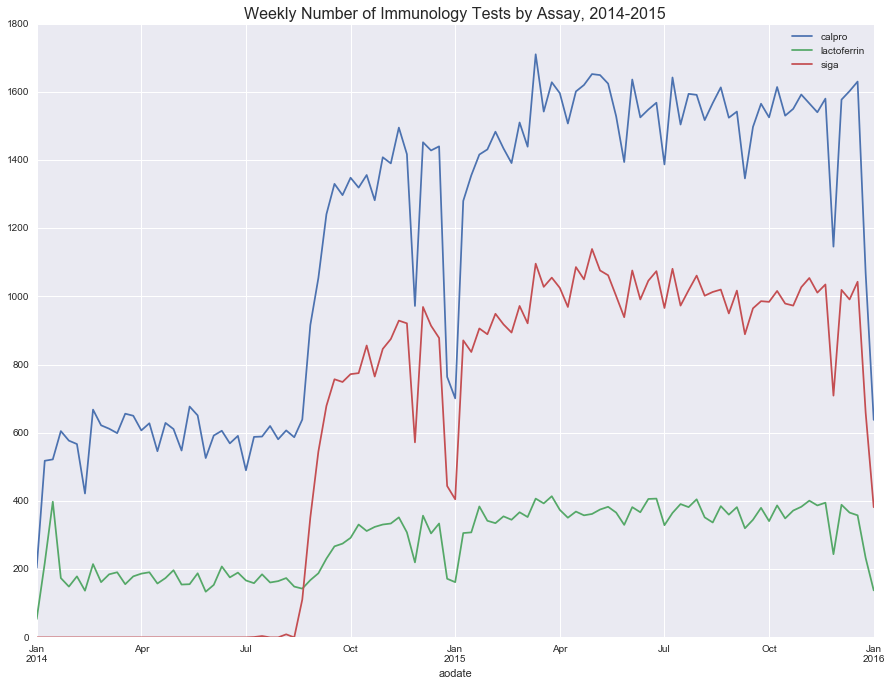

```python
#Plot of volume by test.
sns.set_style("darkgrid")
imm.set_index('aodate')[['calpro','lactoferrin','siga']].resample("W").count().plot(figsize=[15,11])
plt.title("Weekly Number of Immunology Tests by Assay, 2014-2015", size=16);
```

```python
#Clean up and standardize results.
imm.calpro_results = imm.calpro_results.str.replace("^<", "")
imm.calpro_results = imm.calpro_results.str.strip().replace(to_replace='>', value='', regex=True)
imm.calpro_results = pd.to_numeric(imm.calpro_results, errors="ignore")
imm.sigma_results = pd.to_numeric(imm.siga_results, errors="ignore")
imm.loc[imm.calpro_results == "", "calpro_results"] = "."
imm.loc[imm.siga_results == "", "siga_results"] = "."
```

## Lactoferrin Descriptive Statistics

```python
#Lactoferrin results are postive or negative.
#A number of results have "." reported.
#These seem to be a mixture of canceled orders and tests that were ordered but never resulted.
#Possibly due to botched collections where associated tests were not reported?
#Only the postive and negative results will be used in the analysis.
imm.lactoferrin_results.value_counts()
```

```
Negative        27507
.                1665
Positive          669
Test Pending        5
Name: lactoferrin_results, dtype: int64
```

```python
print("Overall positivity of lactoferrin assay: {:.2f}%".format((imm.lactoferrin_results.value_counts()[2]/(imm.lactoferrin_results.value_counts()[0] + imm.lactoferrin_results.value_counts()[2])) * 100))
```

```
Overall positivity of lactoferrin assay: 2.37%
```

## sIgA Descriptive Statistics

```python
#Similarly for sIgA. The "." value reported seems to correspond to canceled orders and specimin
#problems where the associated tests were not reported. The <dl and >ul values seem to correspond
#to extreme values on both ends of the reported range. Since they are not actual values they will
#be held out of the analysis for now.

#Five most common sIgA values:
imm.siga_results.value_counts().head()
```

```
<dl    6493
.      3109
44      191
45      187
57      186
Name: siga_results, dtype: int64
```

```python
#Descriptive statistics for sIgA results.
imm.siga_results[(imm.siga_results != ".")\
                              & (imm.siga_results != "QNS")\
                              & (imm.siga_results != ">ul")\
                              & (imm.siga_results != "<dl")].dropna().astype("int").describe()
```

```
count    55168.000000
mean       510.799775
std        545.826721
min          0.000000
25%        120.000000
50%        319.000000
75%        729.000000
max       7343.000000
Name: siga_results, dtype: float64
```

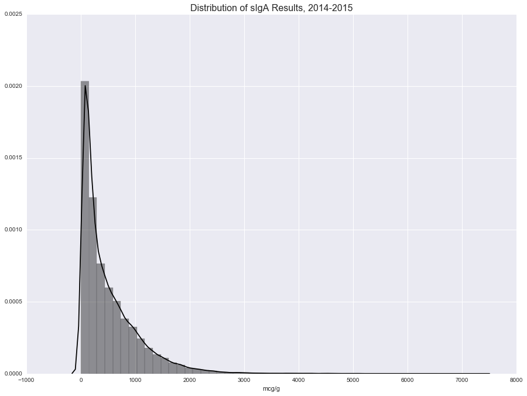

```python
#Distribution of sIgA results.
sns.set_style("darkgrid")
fig = plt.figure(figsize=[15,11])
sns.distplot(imm.siga_results[(imm.siga_results != ".")\
                              & (imm.siga_results != "QNS")\
                              & (imm.siga_results != ">ul")\
                              & (imm.siga_results != "<dl")].dropna().astype("int"), color="black")
plt.title("Distribution of sIgA Results, 2014-2015", size=16)
plt.xlabel("mcg/g");
```

## Calprotectin Descriptive Statistics

```python
#Similarly for calprotectin "." is a common result and will be left out of the analysis.
#Five most commom calprotectin values:
imm.calpro_results.value_counts().head()
```

```
16    39732
17    31723
.      4571
18     1690
19     1397
Name: calpro_results, dtype: int64
```

```python
#Descriptive statistics for calprotectin results.
imm.calpro_results[imm.calpro_results!="."].dropna().astype('int').describe()
```

```
count    116839.000000
mean        105.991689
std         331.173737
min           0.000000
25%          16.000000
50%          17.000000
75%          38.000000
max        2639.000000
Name: calpro_results, dtype: float64
```

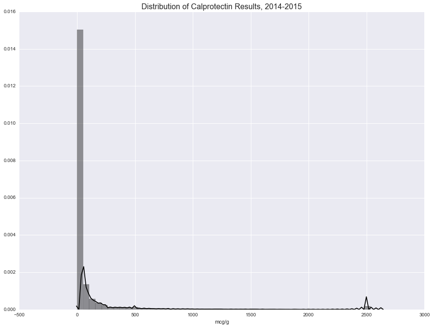

```python
#Distribution of calprotectin results.
sns.set_style("darkgrid")
fig = plt.figure(figsize=[15,11])
sns.distplot(imm.calpro_results[imm.calpro_results != "."].dropna().astype('int'), color="black")
plt.title("Distribution of Calprotectin Results, 2014-2015", size=16)
plt.xlabel("mcg/g");
```

## Create Parasitology Subgroup and Merge Immunology Data

```python
#Create subgroups of parasitology results.
para_results["any_positive"] = "Negative"
para_results["blasto_crypto_giardia_positive"] = "Negative"
para_results["blasto_positive"] = "Negative"
para_results["crypto_positive"] = "Negative"
para_results["giardia_positive"] = "Negative"

#Assign positive values to particular group.
para_results.loc[para_results.RNONE != "RNONE", "any_positive"] = "Positive"
para_results.loc[para_results.RBHOM.notnull(), "blasto_positive"] = "Positive"
para_results.loc[(para_results.RBHOM.notnull()) | (para_results.RGIAR.notnull()) | (para_results.EIAG.notnull()) | (para_results.EIAC.notnull()), "blasto_crypto_giardia_positive"] = "Positive"
para_results.loc[(para_results.EIAC.notnull()), "crypto_positive"] = "Positive"
para_results.loc[(para_results.RGIAR.notnull()) | (para_results.EIAG.notnull()), "giardia_positive"] = "Positive"
```

```python
#Select derived columns of interest from parasitology data.
para_results = para_results[["Order", "any_positive", "blasto_crypto_giardia_positive", "blasto_positive", "crypto_positive", "giardia_positive"]]
para_results = para_results.rename(columns={"Order":"asord"})
para_results.head()
```

|  | asord | any_positive | blasto_crypto_giardia_positive | blasto_positive | crypto_positive | giardia_positive |
| --- | --- | --- | --- | --- | --- | --- |
| 0 | G9020110 | Negative | Negative | Negative | Negative | Negative |
| 1 | G9020113 | Negative | Negative | Negative | Negative | Negative |
| 2 | G9020118 | Negative | Negative | Negative | Negative | Negative |
| 3 | G9020120 | Negative | Negative | Negative | Negative | Negative |
| 4 | G9020121 | Negative | Negative | Negative | Negative | Negative |

```python
#Samples positive for any parasite.
para_results.any_positive.value_counts()
```

```
Negative    115093
Positive     14079
Name: any_positive, dtype: int64
```

```python
#Samples positive for blasto, crypto, or giardia.
para_results.blasto_crypto_giardia_positive.value_counts()
```

```
Negative    118725
Positive     10447
Name: blasto_crypto_giardia_positive, dtype: int64
```

```python
#Samples positive for blasto.
para_results.blasto_positive.value_counts()
```

```
Negative    118993
Positive     10179
Name: blasto_positive, dtype: int64
```

```python
#Samples positive for giardia.
para_results.giardia_positive.value_counts()
```

```
Negative    128850
Positive       322
Name: giardia_positive, dtype: int64
```

```python
#Samples positive for crypto.
para_results.crypto_positive.value_counts()
```

```
Negative    129115
Positive        57
Name: crypto_positive, dtype: int64
```

```python
#Merge immuno and parasitology results.
#Resulting table shows every sample that has immunology and parasitology data.
para_immuno = imm.merge(para_results)
para_immuno.head()
```

|  | asord | aodate | calpro | calpro_results | lactoferrin | lactoferrin_results | siga | siga_results | any_positive | blasto_crypto_giardia_positive | blasto_positive | crypto_positive | giardia_positive |
| --- | --- | --- | --- | --- | --- | --- | --- | --- | --- | --- | --- | --- | --- |
| 0 | G9020169 | 2014-01-02 | NaN | NaN | FLF01 | Negative | NaN | NaN | Negative | Negative | Negative | Negative | Negative |
| 1 | G9020197 | 2014-01-02 | CAL1 | 16 | NaN | NaN | NaN | NaN | Negative | Negative | Negative | Negative | Negative |
| 2 | G9020177 | 2014-01-02 | CAL1 | 16 | NaN | NaN | NaN | NaN | Positive | Negative | Negative | Negative | Negative |
| 3 | G9020174 | 2014-01-02 | CAL1 | 24 | NaN | NaN | NaN | NaN | Negative | Negative | Negative | Negative | Negative |
| 4 | G9020118 | 2014-01-02 | CAL1 | 46 | NaN | NaN | NaN | NaN | Negative | Negative | Negative | Negative | Negative |

```python
#Summary of immunology/parasitology data.
para_immuno.describe()
```

|  | asord | aodate | calpro | calpro_results | lactoferrin | lactoferrin_results | siga | siga_results | any_positive | blasto_crypto_giardia_positive | blasto_positive | crypto_positive | giardia_positive |
| --- | --- | --- | --- | --- | --- | --- | --- | --- | --- | --- | --- | --- | --- |
| count | 92260 | 92260 | 82608 | 82608 | 22702 | 22702 | 62137 | 62137 | 92260 | 92260 | 92260 | 92260 | 92260 |
| unique | 92260 | 614 | 2 | 463 | 2 | 4 | 1 | 2742 | 2 | 2 | 2 | 2 | 2 |
| top | H5160719 | 2015-05-28 00:00:00 | CCAL | 16 | FLF03 | Negative | CSIGA | <dl | Negative | Negative | Negative | Negative | Negative |
| freq | 1 | 442 | 62146 | 33562 | 14266 | 21648 | 62137 | 6400 | 82652 | 85089 | 85269 | 92224 | 92038 |
| first | NaN | 2014-01-02 00:00:00 | NaN | NaN | NaN | NaN | NaN | NaN | NaN | NaN | NaN | NaN | NaN |
| last | NaN | 2015-12-30 00:00:00 | NaN | NaN | NaN | NaN | NaN | NaN | NaN | NaN | NaN | NaN | NaN |

## Calprotectin Analysis

```python
#Samples with reported calprotectin and parasitology.
calpro_para = para_immuno[(para_immuno.calpro_results != ".") & (para_immuno.calpro_results.notnull())].reset_index(drop=True)
calpro_para.calpro_results = calpro_para.calpro_results.astype('int')
calpro_para.describe(include="all")
```

|  | asord | aodate | calpro | calpro_results | lactoferrin | lactoferrin_results | siga | siga_results | any_positive | blasto_crypto_giardia_positive | blasto_positive | crypto_positive | giardia_positive |
| --- | --- | --- | --- | --- | --- | --- | --- | --- | --- | --- | --- | --- | --- |
| count | 80574 | 80574 | 80574 | 80574.000000 | 14632 | 14632 | 58403 | 58403 | 80574 | 80574 | 80574 | 80574 | 80574 |
| unique | 80574 | 612 | 2 | NaN | 2 | 4 | 1 | 2712 | 2 | 2 | 2 | 2 | 2 |
| top | H5300868 | 2015-05-28 00:00:00 | CCAL | NaN | FLF03 | Negative | CSIGA | <dl | Negative | Negative | Negative | Negative | Negative |
| freq | 1 | 409 | 60683 | NaN | 13327 | 14128 | 58403 | 6132 | 72484 | 74561 | 74713 | 80542 | 80385 |
| first | NaN | 2014-01-02 00:00:00 | NaN | NaN | NaN | NaN | NaN | NaN | NaN | NaN | NaN | NaN | NaN |
| last | NaN | 2015-12-30 00:00:00 | NaN | NaN | NaN | NaN | NaN | NaN | NaN | NaN | NaN | NaN | NaN |
| mean | NaN | NaN | NaN | 28.017499 | NaN | NaN | NaN | NaN | NaN | NaN | NaN | NaN | NaN |
| std | NaN | NaN | NaN | 45.154453 | NaN | NaN | NaN | NaN | NaN | NaN | NaN | NaN | NaN |
| min | NaN | NaN | NaN | 0.000000 | NaN | NaN | NaN | NaN | NaN | NaN | NaN | NaN | NaN |
| 25% | NaN | NaN | NaN | 16.000000 | NaN | NaN | NaN | NaN | NaN | NaN | NaN | NaN | NaN |
| 50% | NaN | NaN | NaN | 17.000000 | NaN | NaN | NaN | NaN | NaN | NaN | NaN | NaN | NaN |
| 75% | NaN | NaN | NaN | 17.000000 | NaN | NaN | NaN | NaN | NaN | NaN | NaN | NaN | NaN |
| max | NaN | NaN | NaN | 2500.000000 | NaN | NaN | NaN | NaN | NaN | NaN | NaN | NaN | NaN |

```python
#Split calprotectin results into postive and negative parasite groups.
parasite_positive_calpro = para_immuno[(para_immuno.calpro_results != ".") & (para_immuno.calpro_results.notnull()) & (para_immuno.any_positive == "Positive")]
parasite_negative_calpro = para_immuno[(para_immuno.calpro_results != ".") & (para_immuno.calpro_results.notnull()) & (para_immuno.any_positive == "Negative")]
```

```python
#Descriptive statistics for calprotectin results in group positive for any parasite.
parasite_positive_calpro.calpro_results.astype('int').describe()
```

```
count    8090.000000
mean       22.756613
std        34.541985
min         0.000000
25%        16.000000
50%        17.000000
75%        17.000000
max       516.000000
Name: calpro_results, dtype: float64
```

```python
#Descriptive statistics for calprotectin results in group negative for any parasite.
parasite_negative_calpro.calpro_results.astype('int').describe()
```

```
count    72484.000000
mean        28.604671
std         46.159752
min          0.000000
25%         16.000000
50%         17.000000
75%         18.000000
max       2500.000000
Name: calpro_results, dtype: float64
```

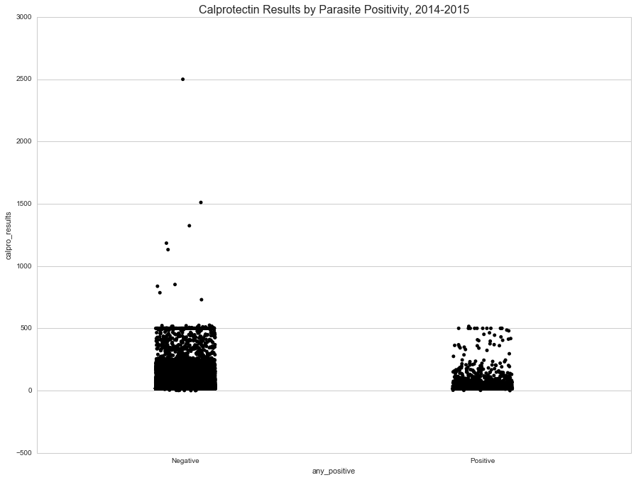

```python
#Plot calprotectin results by positivity for any parasite.
sns.set_style("whitegrid")
fig = plt.figure(figsize=[15,11])
sns.stripplot(x="any_positive", y="calpro_results", data=calpro_para, size=5, color="black", jitter=True)
plt.title("Calprotectin Results by Parasite Positivity, 2014-2015", size=16);
```

```python
#Calculate the nonparametric Mann–Whitney–Wilcoxon rank-sum test, since data is not normally distributed.
#Determine if calprotectin distribution differs between parasite and non-parasite groups.
z, p_value = stats.ranksums(parasite_positive_calpro.calpro_results, parasite_negative_calpro.calpro_results)
print("The p-value is {}, which is less than 0.05. Therefore the null hypothesis that\n\
the parasite-positive calprotectin results come from the same distribution as the\n\
parasite-negative calprotectin results can be rejected.".format(p_value))
```

```
The p-value is 1.4779768614772122e-64, which is less than 0.05. Therefore the null hypothesis that
the parasite-positive calprotectin results come from the same distribution as the
parasite-negative calprotectin results can be rejected.
```

```python
#Fit Bayesian model of calprotectin results by parasite-positive and parasite-negative groups.

parasite_positive_calpro = parasite_positive_calpro.reset_index(drop=True)
parasite_negative_calpro = parasite_negative_calpro.reset_index(drop=True)
parasite_positive_calpro.calpro_results = parasite_positive_calpro.calpro_results.astype('int')
parasite_negative_calpro.calpro_results = parasite_negative_calpro.calpro_results.astype('int')

cp_neg = parasite_negative_calpro.calpro_results + 0.5
cp_pos = parasite_positive_calpro.calpro_results + 0.5

with pm.Model() as model:
    para_neg_lambda = pm.HalfNormal("para_neg_lambda", sd=0.5)
    calpro_para_neg = pm.Exponential("calpro_para_neg", lam=para_neg_lambda, observed=cp_neg)

    para_pos_lambda = pm.HalfNormal("para_pos_lambda", sd=0.5)
    calpro_para_pos = pm.Exponential("calpro_para_pos", lam=para_pos_lambda, observed=cp_pos)

    calpro_diff_of_lambdas = pm.Deterministic("calpro_diff_of_lambdas", para_pos_lambda - para_neg_lambda)

    calpro_para_neg_mean = pm.Deterministic("calpro_para_neg_mean", 1/para_neg_lambda)
    calpro_para_pos_mean = pm.Deterministic("calpro_para_pos_mean", 1/para_pos_lambda)

    calpro_diff_of_means = pm.Deterministic("diff_of_means", calpro_para_neg_mean - calpro_para_pos_mean)

    v_params = pm.variational.advi(n=50000)
    trace = pm.variational.sample_vp(v_params, draws=5000)
```

```
Applied log-transform to para_neg_lambda and added transformed para_neg_lambda_log to model.
Applied log-transform to para_pos_lambda and added transformed para_pos_lambda_log to model.
Iteration 0 [0%]: ELBO = -1732734.35
Iteration 5000 [10%]: ELBO = -409845.36
Iteration 10000 [20%]: ELBO = -354231.13
Iteration 15000 [30%]: ELBO = -350677.9
Iteration 20000 [40%]: ELBO = -350380.59
Iteration 25000 [50%]: ELBO = -350385.09
Iteration 30000 [60%]: ELBO = -350380.0
Iteration 35000 [70%]: ELBO = -350380.47
Iteration 40000 [80%]: ELBO = -350380.51
Iteration 45000 [90%]: ELBO = -350379.57
Finished [100%]: ELBO = -350380.8
```

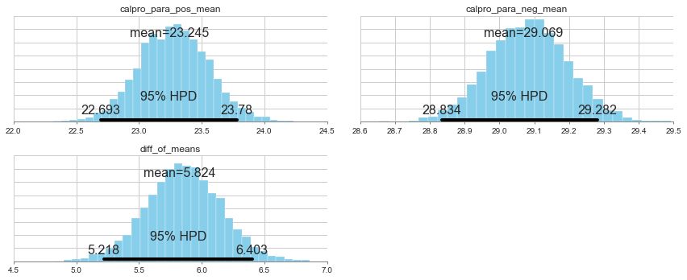

```python
#Plot most likely values for the mean calprotectin results
#for parasite-positive and parasite-negative groups, as well
#as the difference between the means of the two distributions.
pm.plot_posterior(trace[1000:], varnames=["calpro_para_pos_mean", "calpro_para_neg_mean", "diff_of_means"], color='#87ceeb');
```

The model shows the most likely values and uncertainty in the estimate of the means given the data. Since these are probability distributions (unlike classical confidence intervals), you can say that there is a 95% probability that the difference in means is between 5.2 and 6.4 (μg/g). Since this range excludes zero, the parasite-negative group has a significantly higher mean calprotectin level compared to the parasite-positive group. This difference in groups is confirmed by the significant p-value of Mann–Whitney–Wilcoxon rank-sum test above.

## sIgA Analysis

```python
#Samples with reported sIgA and parasitology.
siga_para = para_immuno[(para_immuno.siga_results != ".")\
            & (para_immuno.siga_results != "QNS")\
            & (para_immuno.siga_results != ">ul")\
            & (para_immuno.siga_results != "<dl")\
            & (para_immuno.siga_results.notnull())].reset_index(drop=True)
siga_para["siga_results"] = siga_para["siga_results"].astype('int')
siga_para.describe(include="all")
```

|  | asord | aodate | calpro | calpro_results | lactoferrin | lactoferrin_results | siga | siga_results | any_positive | blasto_crypto_giardia_positive | blasto_positive | crypto_positive | giardia_positive |
| --- | --- | --- | --- | --- | --- | --- | --- | --- | --- | --- | --- | --- | --- |
| count | 54238 | 54238 | 52217 | 52217 | 11889 | 11889 | 54238 | 54238.000000 | 54238 | 54238 | 54238 | 54238 | 54238 |
| unique | 54238 | 414 | 1 | 390 | 1 | 4 | 1 | NaN | 2 | 2 | 2 | 2 | 2 |
| top | J1110872 | 2015-05-28 00:00:00 | CCAL | 16 | FLF03 | Negative | CSIGA | NaN | Negative | Negative | Negative | Negative | Negative |
| freq | 1 | 337 | 52217 | 21080 | 11889 | 11492 | 54238 | NaN | 49933 | 51009 | 51112 | 54218 | 54118 |
| first | NaN | 2014-07-15 00:00:00 | NaN | NaN | NaN | NaN | NaN | NaN | NaN | NaN | NaN | NaN | NaN |
| last | NaN | 2015-12-30 00:00:00 | NaN | NaN | NaN | NaN | NaN | NaN | NaN | NaN | NaN | NaN | NaN |
| mean | NaN | NaN | NaN | NaN | NaN | NaN | NaN | 510.938346 | NaN | NaN | NaN | NaN | NaN |
| std | NaN | NaN | NaN | NaN | NaN | NaN | NaN | 545.118591 | NaN | NaN | NaN | NaN | NaN |
| min | NaN | NaN | NaN | NaN | NaN | NaN | NaN | 1.000000 | NaN | NaN | NaN | NaN | NaN |
| 25% | NaN | NaN | NaN | NaN | NaN | NaN | NaN | 120.000000 | NaN | NaN | NaN | NaN | NaN |
| 50% | NaN | NaN | NaN | NaN | NaN | NaN | NaN | 320.000000 | NaN | NaN | NaN | NaN | NaN |
| 75% | NaN | NaN | NaN | NaN | NaN | NaN | NaN | 730.000000 | NaN | NaN | NaN | NaN | NaN |
| max | NaN | NaN | NaN | NaN | NaN | NaN | NaN | 7343.000000 | NaN | NaN | NaN | NaN | NaN |

```python
#Split sIgA results into postive and negative parasitology groups.
parasite_positive_siga = siga_para[siga_para.any_positive=="Positive"]
parasite_negative_siga = siga_para[siga_para.any_positive=="Negative"]
```

```python
#Descriptive statistics for sIgA results in group positive for any parasite.
parasite_positive_siga.siga_results.describe()
```

```
count    4305.000000
mean      205.518235
std       320.613037
min         1.000000
25%        57.000000
50%       103.000000
75%       208.000000
max      4235.000000
Name: siga_results, dtype: float64
```

```python
#Descriptive statistics for sIgA results in group negative for any parasite.
parasite_negative_siga.siga_results.describe()
```

```
count    49933.000000
mean       537.270302
std        552.421265
min          1.000000
25%        135.000000
50%        356.000000
75%        767.000000
max       7343.000000
Name: siga_results, dtype: float64
```

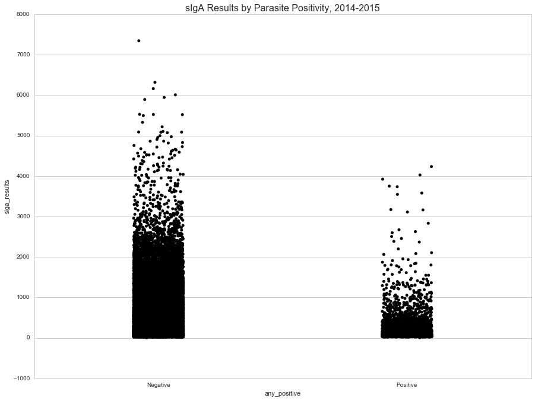

```python
#Plot sIgA results by positivity for any parasite.
sns.set_style("whitegrid")
fig = plt.figure(figsize=[15,11])
sns.stripplot(x="any_positive", y="siga_results", data=siga_para, size=5, color="black", jitter=True)
plt.title("sIgA Results by Parasite Positivity, 2014-2015", size=16);
```

```python
#Calculate the nonparametric Mann–Whitney–Wilcoxon rank-sum test.
#Determine if sIgA distribution differs between parasite and non-parasite groups.
z, p_value = stats.ranksums(parasite_positive_siga.siga_results, parasite_negative_siga.siga_results)
print("The p-value is {}, which is less than 0.05. Therefore the null hypothesis that\n\
the parasite-positive sIgA results come from the same distribution as the\n\
parasite-negative sIgA results can be rejected.".format(p_value))
```

```
The p-value is 0.0, which is less than 0.05. Therefore the null hypothesis that
the parasite-positive sIgA results come from the same distribution as the
parasite-negative sIgA results can be rejected.
```

```python
#Fit Bayesian model of sIgA results by parasite-positive and parasite-negative groups.

sa_pos = parasite_positive_siga.siga_results
sa_neg = parasite_negative_siga.siga_results

with pm.Model() as model:
    siga_para_neg_lambda = pm.HalfNormal("siga_para_neg_lambda", sd=0.5)
    siga_para_neg = pm.Exponential("siga_para_neg", lam=siga_para_neg_lambda, observed=sa_neg)

    siga_para_pos_lambda = pm.HalfNormal("siga_para_pos_lambda", sd=0.5)
    siga_para_pos = pm.Exponential("siga_para_pos", lam=siga_para_pos_lambda, observed=sa_pos)

    diff_of_lam = pm.Deterministic("diff_of_lam", siga_para_pos_lambda - siga_para_neg_lambda)

    siga_para_neg_mean = pm.Deterministic("siga_para_neg_mean", 1/siga_para_neg_lambda)
    siga_para_pos_mean = pm.Deterministic("siga_para_pos_mean", 1/siga_para_pos_lambda)

    diff_of_means = pm.Deterministic("diff_of_means", siga_para_neg_mean - siga_para_pos_mean)

    #start = pm.find_MAP(model=model)
    #trace = pm.sample(10000, start=start)
    v_params = pm.variational.advi(n=50000)
    trace = pm.variational.sample_vp(v_params, draws=5000)
    #trace['siga_para_neg_lambda'] < trace['siga_para_pos_lambda']).mean()
```

```
Applied log-transform to siga_para_neg_lambda and added transformed siga_para_neg_lambda_log to model.
Applied log-transform to siga_para_pos_lambda and added transformed siga_para_pos_lambda_log to model.
Iteration 0 [0%]: ELBO = -21468563.89
Iteration 5000 [10%]: ELBO = -2593747.56
Iteration 10000 [20%]: ELBO = -1190098.9
Iteration 15000 [30%]: ELBO = -418379.29
Iteration 20000 [40%]: ELBO = -391101.34
Iteration 25000 [50%]: ELBO = -391150.25
Iteration 30000 [60%]: ELBO = -391085.87
Iteration 35000 [70%]: ELBO = -391087.8
Iteration 40000 [80%]: ELBO = -391087.41
Iteration 45000 [90%]: ELBO = -391086.37
Finished [100%]: ELBO = -391087.42
```

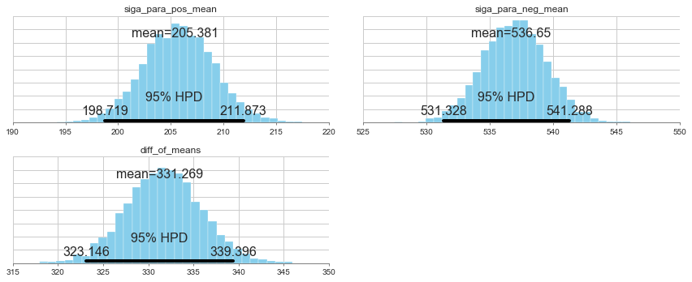

```python
#Plot most likely values for the mean sIgA results
#for parasite-positive and parasite-negative groups, as well
#as the difference between the means of the two distributions.
pm.plot_posterior(trace[1000:], varnames=["siga_para_pos_mean", "siga_para_neg_mean", "diff_of_means"], color='#87ceeb');
```

The model shows the most likely values and uncertainty in the estimate of the means given the data. Since these are probability distributions (unlike classical confidence intervals), you can say that there is a 95% probability that the difference in means is between 323 and 339 (μg/g). Since this range excludes zero, the parasite-negative group has a significantly higher mean sIgA level compared to the parasite-positive group. This difference in groups is confirmed by the significant p-value of Mann–Whitney–Wilcoxon rank-sum test above.

## Lactoferrin Analysis

```python
#Samples with reported lactoferrin and parasitology.
lacto_para = para_immuno[(para_immuno.lactoferrin_results == "Positive") | (para_immuno.lactoferrin_results == "Negative")].reset_index(drop=True)
lacto_para.describe()
```

|  | asord | aodate | calpro | calpro_results | lactoferrin | lactoferrin_results | siga | siga_results | any_positive | blasto_crypto_giardia_positive | blasto_positive | crypto_positive | giardia_positive |
| --- | --- | --- | --- | --- | --- | --- | --- | --- | --- | --- | --- | --- | --- |
| count | 22174 | 22174 | 14730 | 14730 | 22174 | 22174 | 13311 | 13311 | 22174 | 22174 | 22174 | 22174 | 22174 |
| unique | 22174 | 601 | 2 | 292 | 2 | 2 | 1 | 1949 | 2 | 2 | 2 | 2 | 2 |
| top | I6180569 | 2015-03-25 00:00:00 | CCAL | 16 | FLF03 | Negative | CSIGA | <dl | Negative | Negative | Negative | Negative | Negative |
| freq | 1 | 113 | 13387 | 5832 | 14132 | 21648 | 13311 | 1358 | 19916 | 20436 | 20481 | 22169 | 22116 |
| first | NaN | 2014-01-02 00:00:00 | NaN | NaN | NaN | NaN | NaN | NaN | NaN | NaN | NaN | NaN | NaN |
| last | NaN | 2015-12-30 00:00:00 | NaN | NaN | NaN | NaN | NaN | NaN | NaN | NaN | NaN | NaN | NaN |

```python
#Split lactoferrin results into postive and negative parasitology groups.
parasite_positive_lacto = lacto_para[lacto_para.any_positive=="Positive"].reset_index(drop=True)
parasite_negative_lacto = lacto_para[lacto_para.any_positive=="Negative"].reset_index(drop=True)
```

```python
#Lactoferrin results for positive parasite group.
parasite_positive_lacto.lactoferrin_results.value_counts()
```

```
Negative    2232
Positive      26
Name: lactoferrin_results, dtype: int64
```

```python
#Lactoferrin results for negative parasite group.
parasite_negative_lacto.lactoferrin_results.value_counts()
```

```
Negative    19416
Positive      500
Name: lactoferrin_results, dtype: int64
```

```python
#Calculate percentage for positive parasite group.
print("Overall lactoferrin positivity for samples positive for parasites: {:.2f}%".format(parasite_positive_lacto.lactoferrin_results.value_counts()[1]/(parasite_positive_lacto.lactoferrin_results.value_counts()[0] + parasite_positive_lacto.lactoferrin_results.value_counts()[1]) * 100))
```

```
Overall lactoferrin positivity for samples positive for parasites: 1.15%
```

```python
#Calculate percentage for negative parasite group.
print("Overall lactoferrin positivity for samples negative for parasites: {:.2f}%".format(parasite_negative_lacto.lactoferrin_results.value_counts()[1]/(parasite_negative_lacto.lactoferrin_results.value_counts()[0] + parasite_negative_lacto.lactoferrin_results.value_counts()[1])*100))
```

```
Overall lactoferrin positivity for samples negative for parasites: 2.51%
```

```python
#Create new column with binary (0/1) marker of lactoferrin positivity.
parasite_positive_lacto["lacto_results_binary"] = 0
parasite_negative_lacto["lacto_results_binary"] = 0
parasite_positive_lacto.loc[parasite_positive_lacto.lactoferrin_results == "Positive", "lacto_results_binary"] = 1
parasite_negative_lacto.loc[parasite_negative_lacto.lactoferrin_results == "Positive", "lacto_results_binary"] = 1
```

```python
#Generate bootstrap sample of average lactoferrin positivity for each group.
parasite_positive_lacto_bootstrap_mean = [np.random.choice(parasite_positive_lacto.lacto_results_binary.values, parasite_positive_lacto.shape[0]).mean() * 100 for i in range(1000)]
parasite_negative_lacto_bootstrap_mean = [np.random.choice(parasite_negative_lacto.lacto_results_binary.values, parasite_negative_lacto.shape[0]).mean() * 100 for i in range(1000)]
parasite_group_lacto_difference = [(np.random.choice(parasite_negative_lacto.lacto_results_binary.values, parasite_negative_lacto.shape[0]).mean() * 100) - (np.random.choice(parasite_positive_lacto.lacto_results_binary.values, parasite_positive_lacto.shape[0]).mean() * 100) for i in range(5000)]
```

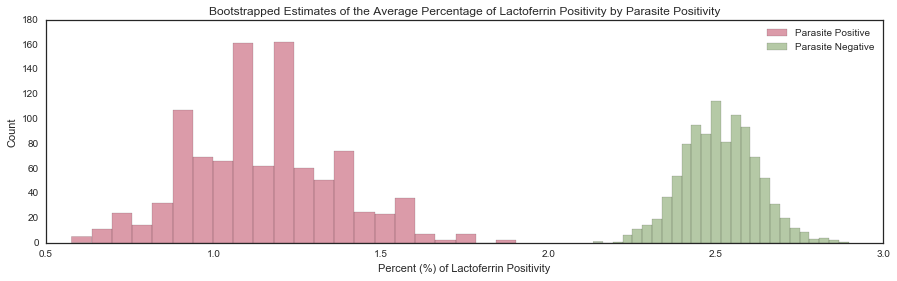

```python
#Plot lactoferrin average percent distribution for each group.
sns.set_style("white")
colors = ["#348ABD", "#A60628", "#7A68A6", "#467821"]
plt.figure(figsize=[15,4])
ax = sns.distplot(parasite_positive_lacto_bootstrap_mean, kde=False, color=colors[1], label="Parasite Positive")
ax = sns.distplot(parasite_negative_lacto_bootstrap_mean, kde=False, color=colors[3], label="Parasite Negative")
plt.title("Bootstrapped Estimates of the Average Percentage of Lactoferrin Positivity by Parasite Positivity")
ax.set_ylabel("Count")
ax.set_xlabel("Percent (%) of Lactoferrin Positivity")
plt.legend();
```

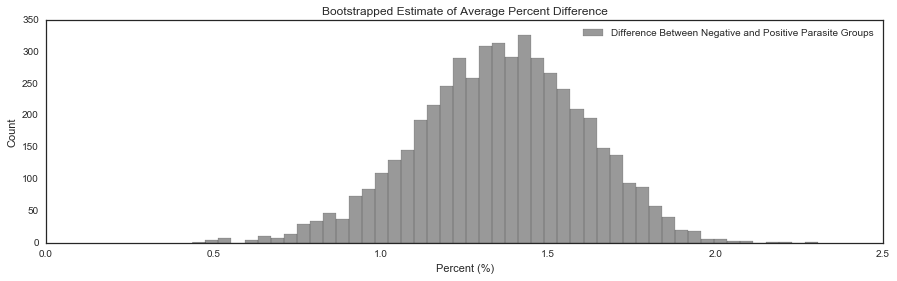

```python
#Plot average lactoferrin percentage that the negative parasite group is higher than positive parasite group.
sns.set_style("white")
colors = ["#348ABD", "#A60628", "#7A68A6", "#467821"]
plt.figure(figsize=[15,4])
ax = sns.distplot(parasite_group_lacto_difference, kde=False, color="k", label="Difference Between Negative and Positive Parasite Groups")
plt.title("Bootstrapped Estimate of Average Percent Difference")
ax.set_ylabel("Count")
ax.set_xlabel("Percent (%)")
plt.legend();
```

```python
pd.crosstab(lacto_para.lactoferrin_results, lacto_para.any_positive)
```

| any_positive lactoferrin_results | Negative | Positive |
| --- | --- | --- |
| Negative | 19416 | 2232 |
| Positive | 500 | 26 |

```python
#Assign above crosstab results to variables to use in Chi-squared test for categorical data.
n_lacto_neg_para_neg = pd.crosstab(lacto_para.lactoferrin_results, lacto_para.any_positive)["Negative"][0]
n_lacto_pos_para_neg = pd.crosstab(lacto_para.lactoferrin_results, lacto_para.any_positive)["Negative"][1]
n_lacto_neg_para_pos = pd.crosstab(lacto_para.lactoferrin_results, lacto_para.any_positive)["Positive"][0]
n_lacto_pos_para_pos = pd.crosstab(lacto_para.lactoferrin_results, lacto_para.any_positive)["Positive"][1]
n_tests_para_neg = pd.crosstab(lacto_para.lactoferrin_results, lacto_para.any_positive).sum()[0]
n_test_para_pos = pd.crosstab(lacto_para.lactoferrin_results, lacto_para.any_positive).sum()[1]
```

```python
#Run Chi-squared test for categorical data. Print p_value, expected table, and actual table.
chi, p_value, tables = sm.stats.proportions_chisquare([n_lacto_pos_para_neg, n_lacto_pos_para_pos], [n_tests_para_neg, n_test_para_pos])
actual = tables[0]
expected = tables[1]
print("The p-value is {}, which is less than 0.05, so the null hypothesis\
 that the\npositive and negative parasite groups have the same proportion\
 of positive lactoferrin tests\ncan be rejected. This agrees with the above\
 difference in the bootstrapped estimates of the mean.".format(p_value))
print("\nExpected proportions if groups were the same:\n", expected)
print("\nActual proportions observed:\n", actual)
```

```
The p-value is 5.7735243847577054e-05, which is less than 0.05, so the null hypothesis that the
positive and negative parasite groups have the same proportion of positive lactoferrin tests
can be rejected. This agrees with the above difference in the bootstrapped estimates of the mean.

Expected proportions if groups were the same:
 [[   472.43690809  19443.56309191]
 [    53.56309191   2204.43690809]]

Actual proportions observed:
 [[  500 19416]
 [   26  2232]]
```

```python
#Fit Bayesian model of lactoferrin positivity by parasite-positive and parasite-negative groups.

with pm.Model() as model:
    para_negative_rate = pm.Uniform('para_negative_rate', lower=0, upper=1)
    lacto_positive_para_negative = pm.Binomial('lacto_positive_para_negative', len(parasite_negative_lacto.lacto_results_binary), para_negative_rate, observed=parasite_negative_lacto.lacto_results_binary.sum())
    para_positive_rate = pm.Uniform('para_positive_rate')
    lacto_positive_para_positive = pm.Binomial('lacto_positive_para_positive', len(parasite_positive_lacto.lacto_results_binary), para_positive_rate, observed=parasite_positive_lacto.lacto_results_binary.sum())
    lacto_para_neg_percent = pm.Deterministic("lacto_para_neg_percent", para_negative_rate*100)
    lacto_para_pos_percent = pm.Deterministic("lacto_para_pos_percent", para_positive_rate*100)
    diff_in_percent = pm.Deterministic("diff_in_percent", lacto_para_neg_percent - lacto_para_pos_percent)
    start = pm.find_MAP(model=model)
    trace = pm.sample(10000, start=start)
```

```
Applied interval-transform to para_negative_rate and added transformed para_negative_rate_interval to model.
Applied interval-transform to para_positive_rate and added transformed para_positive_rate_interval to model.
Assigned NUTS to para_negative_rate_interval
Assigned NUTS to para_positive_rate_interval
 [-----------------100%-----------------] 10000 of 10000 complete in 5.5 sec
```

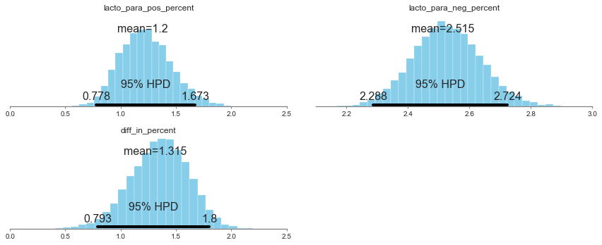

```python
#Plot most likely values for the mean lactoferrin positivity
#for parasite-positive and parasite-negative groups, as well
#as the difference between the mean percentage of the two distributions.
pm.plot_posterior(trace[1000:], varnames=["lacto_para_pos_percent", "lacto_para_neg_percent", "diff_in_percent"], color='#87ceeb');
```

The model shows the most likely values and uncertainty in the estimate of the mean lactoferrin positivity given the data. Since these are probability distributions (unlike classical confidence intervals), you can say that there is a 95% probability that the difference in percentage is between 0.8% and 1.8%. Since this range excludes zero, the parasite-negative group has a significantly higher lactoferrin positivity compared to the parasite-positive group. This difference in groups is confirmed by the significant p-value of Chi-squared test for categorical data above. In this case the 95% Bayesian credible intervals agree very closely with the 95% confidence intervals obtained from the above bootstrapping.

```python
#Cast lacto and parasite positivity to binary.
lacto_para["lacto_para_results_binary"] = 0
lacto_para.loc[lacto_para.lactoferrin_results == "Positive", "lacto_para_results_binary"] = 1
lacto_para["lacto_para_any_positive_binary"] = 0
lacto_para.loc[lacto_para.any_positive == "Positive", "lacto_para_any_positive_binary"] = 1
```

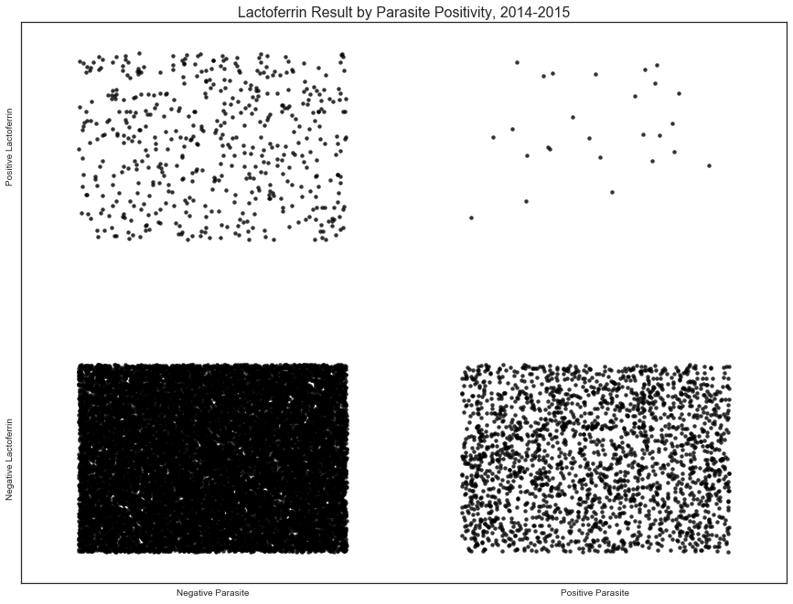

```python
#Visualize results by category.
#Lactoferrin positivy versus parasite positivity.
sns.set_style("white")
fig = plt.figure(figsize=[15,11])
ax = sns.regplot(x="lacto_para_any_positive_binary", y="lacto_para_results_binary", data=lacto_para, color="black", fit_reg=False, x_jitter=0.35, y_jitter=0.3)
plt.title("Lactoferrin Result by Parasite Positivity, 2014-2015", size=16)
ax.set_xticks([0,1])
ax.set_yticks([0,1])
ax.set_xticklabels(["Negative Parasite", "Positive Parasite"])
ax.set_yticklabels(["Negative Lactoferrin", "Positive Lactoferrin"], rotation=90)
ax.set_xlabel('')
ax.set_ylabel('');
```

## Visualization of samples that have all three immunology markers reported (~11,000)

```python
#Select samples that have all three immunology markers reported and parasitology results.
all_immuno_markers = para_immuno[(para_immuno.lactoferrin.notnull()) & (para_immuno.siga.notnull()) & (para_immuno.calpro.notnull())]
all_immuno_markers.describe()
```

|  | asord | aodate | calpro | calpro_results | lactoferrin | lactoferrin_results | siga | siga_results | any_positive | blasto_crypto_giardia_positive | blasto_positive | crypto_positive | giardia_positive |
| --- | --- | --- | --- | --- | --- | --- | --- | --- | --- | --- | --- | --- | --- |
| count | 12948 | 12948 | 12948 | 12948 | 12948 | 12948 | 12948 | 12948 | 12948 | 12948 | 12948 | 12948 | 12948 |
| unique | 12948 | 410 | 1 | 272 | 1 | 4 | 1 | 1939 | 2 | 2 | 2 | 2 | 2 |
| top | I6180569 | 2015-03-25 00:00:00 | CCAL | 16 | FLF03 | Negative | CSIGA | <dl | Negative | Negative | Negative | Negative | Negative |
| freq | 1 | 97 | 12948 | 5084 | 12948 | 12509 | 12948 | 1313 | 11932 | 12190 | 12212 | 12946 | 12922 |
| first | NaN | 2014-07-15 00:00:00 | NaN | NaN | NaN | NaN | NaN | NaN | NaN | NaN | NaN | NaN | NaN |
| last | NaN | 2015-12-30 00:00:00 | NaN | NaN | NaN | NaN | NaN | NaN | NaN | NaN | NaN | NaN | NaN |

```python
#Select samples with valid immuno results.
all_immuno_markers = all_immuno_markers[(all_immuno_markers.siga_results != ".")\
                                          & (all_immuno_markers.siga_results != "QNS")\
                                          & (all_immuno_markers.siga_results != ">ul")\
                                          & (all_immuno_markers.siga_results != "<dl")\
                                          & (all_immuno_markers.calpro_results != ".")\
                                          & ((all_immuno_markers.lactoferrin_results == "Positive")\
                                                | (all_immuno_markers.lactoferrin_results == "Negative"))].reset_index(drop=True)
all_immuno_markers.describe()
```

|  | asord | aodate | calpro | calpro_results | lactoferrin | lactoferrin_results | siga | siga_results | any_positive | blasto_crypto_giardia_positive | blasto_positive | crypto_positive | giardia_positive |
| --- | --- | --- | --- | --- | --- | --- | --- | --- | --- | --- | --- | --- | --- |
| count | 11346 | 11346 | 11346 | 11346 | 11346 | 11346 | 11346 | 11346 | 11346 | 11346 | 11346 | 11346 | 11346 |
| unique | 11346 | 407 | 1 | 268 | 1 | 2 | 1 | 1928 | 2 | 2 | 2 | 2 | 2 |
| top | I6180569 | 2015-03-25 00:00:00 | CCAL | 16 | FLF03 | Negative | CSIGA | 48 | Negative | Negative | Negative | Negative | Negative |
| freq | 1 | 86 | 11346 | 4519 | 11346 | 11056 | 11346 | 49 | 10589 | 10783 | 10804 | 11344 | 11322 |
| first | NaN | 2014-07-15 00:00:00 | NaN | NaN | NaN | NaN | NaN | NaN | NaN | NaN | NaN | NaN | NaN |
| last | NaN | 2015-12-30 00:00:00 | NaN | NaN | NaN | NaN | NaN | NaN | NaN | NaN | NaN | NaN | NaN |

```python
#Cast lactoferrin and any_positive columns to binary.
all_immuno_markers["lactoferrin_results_binary"] = 0
all_immuno_markers.loc[all_immuno_markers.lactoferrin_results == "Positive", "lactoferrin_results_binary"] = 1
all_immuno_markers["any_positive_binary"] = 0
all_immuno_markers.loc[all_immuno_markers.any_positive == "Positive", "any_positive_binary"] = 1
all_immuno_markers.calpro_results = all_immuno_markers.calpro_results.astype('int')
all_immuno_markers.siga_results = all_immuno_markers.siga_results.astype('int')
```

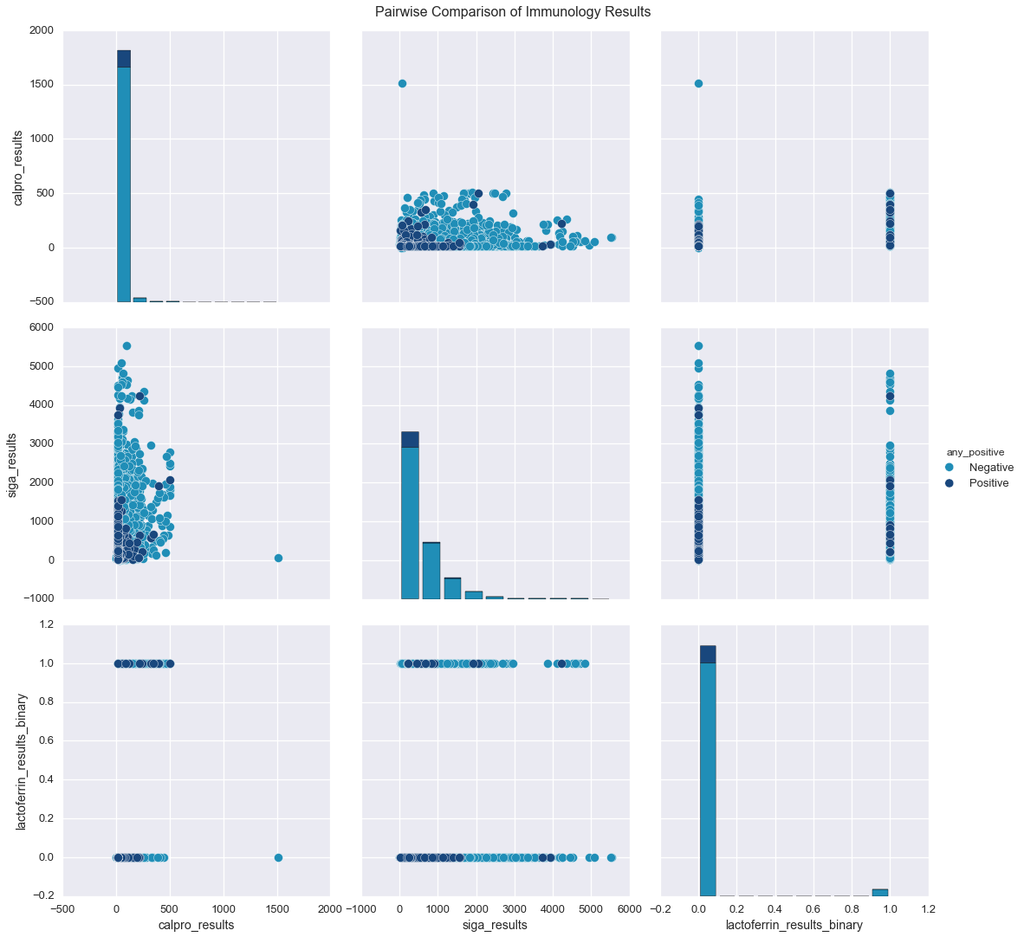

```python
#Plot pairwise comparison of immunology results for samples that have all three markers reported.
#Color by parasite positive or negative.
sns.set(style="darkgrid")
sns.set_context("talk")
ax = sns.pairplot(all_immuno_markers[["calpro_results", "siga_results", "lactoferrin_results_binary", "any_positive"]],\
                  vars=["calpro_results", "siga_results", "lactoferrin_results_binary"],\
                  hue="any_positive", size=5, palette=["#208eb7", "#19477d"], plot_kws={"s": 100})
plt.suptitle("Pairwise Comparison of Immunology Results", y=1.005, size=16);
```

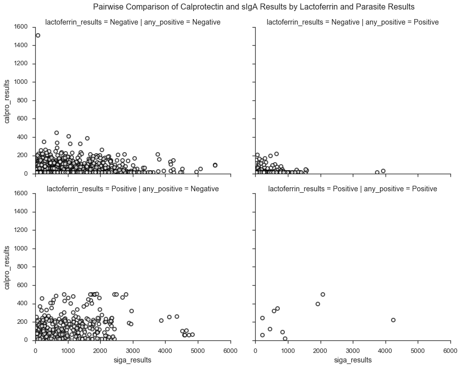

```python
#Plot sIgA versus calprotectin results by every combination of lactoferrin/parasite positive/negative.
sns.set(style="ticks")
sns.set_context("talk")
ax = sns.FacetGrid(all_immuno_markers, col="any_positive", row="lactoferrin_results", size=5, aspect=1.3)
ax = ax.map(plt.scatter, "siga_results", "calpro_results", color="white", s=50, edgecolor="black", lw=2, alpha=0.7)
plt.suptitle("Pairwise Comparison of Calprotectin and sIgA Results by Lactoferrin and Parasite Results", x=0.55, y=1.02, size=16)
plt.gca().set_xlim(left=0)
plt.gca().set_ylim(bottom=0);
```

## Visualization of samples that have calprotectin and sIgA reported (~52,000)

```python
#Subselect only samples that have both calprotectin and siga results.
calpro_and_siga_samples  = para_immuno[(para_immuno.siga.notnull())\
                                    & (para_immuno.calpro.notnull())\
                                    & (para_immuno.siga_results != "QNS")\
                                    & (para_immuno.siga_results != ">ul")\
                                    & (para_immuno.siga_results != ".")\
                                    & (para_immuno.siga_results != "<dl")\
                                    & (para_immuno.calpro_results != ".")].reset_index(drop=True)
calpro_and_siga_samples.calpro_results = calpro_and_siga_samples.calpro_results.astype("int")
calpro_and_siga_samples.siga_results = calpro_and_siga_samples.siga_results.astype("int")
calpro_and_siga_samples.describe(include="all")
```

|  | asord | aodate | calpro | calpro_results | lactoferrin | lactoferrin_results | siga | siga_results | any_positive | blasto_crypto_giardia_positive | blasto_positive | crypto_positive | giardia_positive |
| --- | --- | --- | --- | --- | --- | --- | --- | --- | --- | --- | --- | --- | --- |
| count | 52112 | 52112 | 52112 | 52112.000000 | 11442 | 11442 | 52112 | 52112.000000 | 52112 | 52112 | 52112 | 52112 | 52112 |
| unique | 52112 | 414 | 1 | NaN | 1 | 4 | 1 | NaN | 2 | 2 | 2 | 2 | 2 |
| top | J1110872 | 2015-05-28 00:00:00 | CCAL | NaN | FLF03 | Negative | CSIGA | NaN | Negative | Negative | Negative | Negative | Negative |
| freq | 1 | 327 | 52112 | NaN | 11442 | 11056 | 52112 | NaN | 47970 | 49011 | 49110 | 52093 | 51995 |
| first | NaN | 2014-07-15 00:00:00 | NaN | NaN | NaN | NaN | NaN | NaN | NaN | NaN | NaN | NaN | NaN |
| last | NaN | 2015-12-30 00:00:00 | NaN | NaN | NaN | NaN | NaN | NaN | NaN | NaN | NaN | NaN | NaN |
| mean | NaN | NaN | NaN | 27.175564 | NaN | NaN | NaN | 510.444850 | NaN | NaN | NaN | NaN | NaN |
| std | NaN | NaN | NaN | 38.778698 | NaN | NaN | NaN | 543.898804 | NaN | NaN | NaN | NaN | NaN |
| min | NaN | NaN | NaN | 0.000000 | NaN | NaN | NaN | 1.000000 | NaN | NaN | NaN | NaN | NaN |
| 25% | NaN | NaN | NaN | 16.000000 | NaN | NaN | NaN | 120.000000 | NaN | NaN | NaN | NaN | NaN |
| 50% | NaN | NaN | NaN | 17.000000 | NaN | NaN | NaN | 319.000000 | NaN | NaN | NaN | NaN | NaN |
| 75% | NaN | NaN | NaN | 17.000000 | NaN | NaN | NaN | 730.000000 | NaN | NaN | NaN | NaN | NaN |
| max | NaN | NaN | NaN | 1511.000000 | NaN | NaN | NaN | 7343.000000 | NaN | NaN | NaN | NaN | NaN |

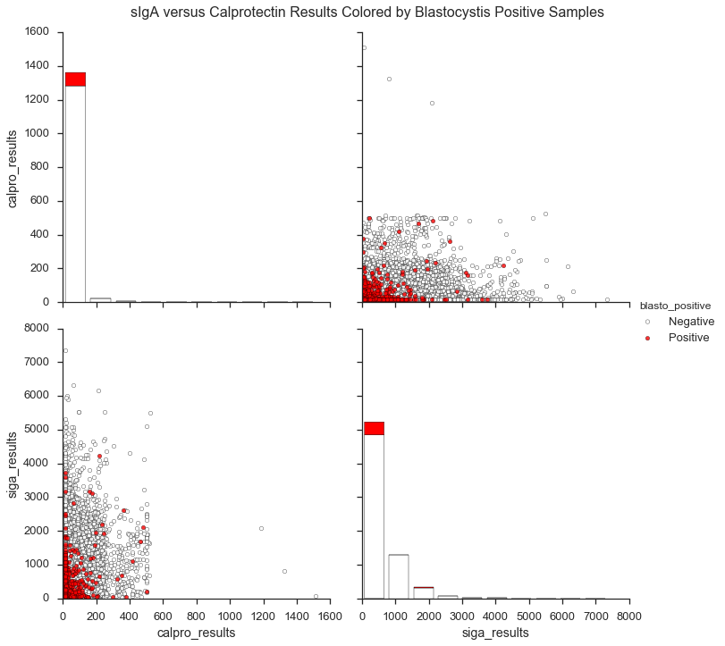

```python
#Plot calprotectin versus sIgA results, colored by samples positive for Blastocystis.
ax = sns.pairplot(calpro_and_siga_samples, vars=["calpro_results", "siga_results"], hue="blasto_positive", palette=["white", "red"], size=5, plot_kws={"edgecolor": "black", "alpha":0.8})
plt.title("sIgA versus Calprotectin Results Colored by Blastocystis Positive Samples", x=0.02, y=1.04, size=16)
ax.set(ylim=(0, None))
ax.set(xlim=(0, None));
```

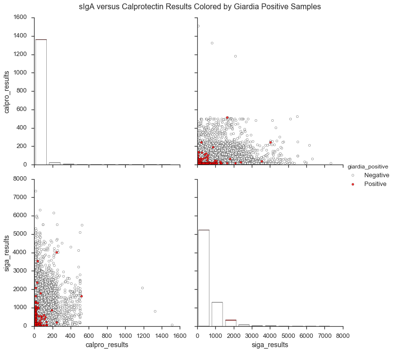

```python
#Plot calprotectin versus sIgA results, colored by samples positive for Giardia.
ax = sns.pairplot(calpro_and_siga_samples, vars=["calpro_results", "siga_results"], hue="giardia_positive", palette=["white", "red"], size=5, plot_kws={"edgecolor": "black", "alpha": 0.8})
plt.title("sIgA versus Calprotectin Results Colored by Giardia Positive Samples", x=0.02, y=1.04, size=16)
ax.set(ylim=(0, None))
ax.set(xlim=(0, None));
```

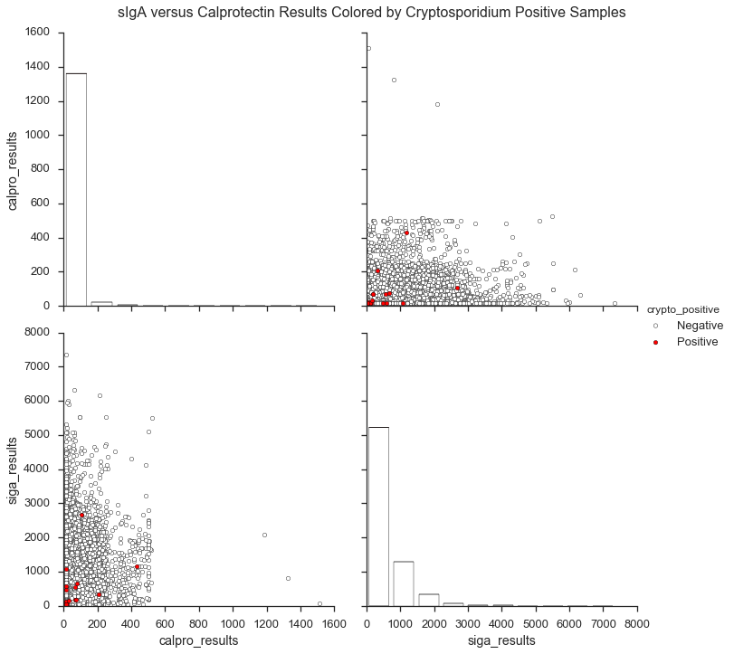

```python
#Plot calprotectin versus sIgA results, colored by samples positive for Cryptosporidium.
ax = sns.pairplot(calpro_and_siga_samples, vars=["calpro_results", "siga_results"], hue="crypto_positive", palette=["white", "red"], size=5, plot_kws={"edgecolor": "black"})
plt.title("sIgA versus Calprotectin Results Colored by Cryptosporidium Positive Samples", x=0.02, y=1.04, size=16)
ax.set(ylim=(0, None))
ax.set(xlim=(0, None));
```

## Logistic Regression

```python
#Fit logistic regression model using calprotectin, sIgA, and
#lactoferrin results as features to predict whether or not
#a sample is in parasite-positive group.
res = logit("any_positive_binary ~ calpro_results + siga_results + lactoferrin_results_binary", all_immuno_markers).fit()
```

```
Optimization terminated successfully.
         Current function value: 0.225995
         Iterations 8
```

```python
#Display summary of logistic regression coefficients.
res.summary()
```

Logit Regression Results

| Dep. Variable: | any_positive_binary | No. Observations: | 11346 |
| --- | --- | --- | --- |
| Model: | Logit | Df Residuals: | 11342 |
| Method: | MLE | Df Model: | 3 |
| Date: | Tue, 30 Aug 2016 | Pseudo R-squ.: | 0.07783 |
| Time: | 22:40:26 | Log-Likelihood: | -2564.1 |
| converged: | True | LL-Null: | -2780.6 |
|  |  | LLR p-value: | 1.705e-93 |

|  | coef | std err | z | P>\|z\| | [95.0% Conf. Int.] |
| --- | --- | --- | --- | --- | --- |
| Intercept | -1.7476 | 0.063 | -27.894 | 0.000 | -1.870 -1.625 |
| calpro_results | -0.0008 | 0.002 | -0.555 | 0.579 | -0.004 0.002 |
| siga_results | -0.0026 | 0.000 | -15.491 | 0.000 | -0.003 -0.002 |
| lactoferrin_results_binary | 0.2296 | 0.376 | 0.610 | 0.542 | -0.508 0.967 |

```python
#Coefficients are reported as log-odds.
#Calculate percent decrease in odds that a sample is positive per unit increase in sIgA.
#i.e. The higher sIgA is the less likely a sample is to be positive for parasites.
(np.exp(-0.0026)-1)*100
```

```
-0.25966229274302366
```

The only significant feature coefficient (p-value less than 0.05) is sIgA. Therefore, calprotectin and lactoferrin have no predictive value as to whether a sample is positive or negative for parasites. The coefficient (reported as the log of the odds that a sample is positive for parasites) for sIgA is negative, which means that the probability that a sample is positive for parasites decreases as sIgA increases. Specifically, the probability that a sample is positive for parasites decreases 0.26% per unit increase in sIgA. This agrees with the differences found in the parasite-positive and parasite-negative groups above (i.e. higher mean value of sIgA in parasite-negative group).

```python
'''
(np.exp(-0.003) - 1)*100

ppc = pm.sample_ppc(trace[1000:], samples=500, model=model, size=100)

sns.distplot(np.array([d for d in ppc['']]).flatten())

sns.set_style("white")
plt.figure(figsize=(7, 7))
pm.traceplot(trace[1000:])
plt.tight_layout();

pm.plot_posterior(trace[1000:], color='#87ceeb');

ax = plt.subplot()
sns.distplot([np.mean(d) for d in ppc['Y_obs1']], kde=False, ax=ax)
ax.axvline(np.mean(np.array(sa_neg)))
ax.set(title='Posterior predictive of the mean', xlabel='mean(x)', ylabel='Frequency');

plt.plot(v_params.elbo_vals)
plt.ylabel('ELBO')
plt.xlabel('Iteration')

'''
```